# Risk Factor Analysis

## Outcome Variable

**Outcome Variable:** wasted

## Predictor Variables

**Intervention Variable:** exclfeed3

**Adjustment Set:**

unadjusted

## Stratifying Variables

The analysis was stratified on these variable(s):

- agecat
- studyid
- country

## Data Summary

| agecat | studyid | country | exclfeed3 | wasted | n_cell | n | outcome_variable |
| --- | --- | --- | --- | --- | --- | --- | --- |
| Birth | ki0047075b-MAL-ED | BANGLADESH | 1 | 0 | 109 | 202 | wasted |
| Birth | ki0047075b-MAL-ED | BANGLADESH | 1 | 1 | 21 | 202 | wasted |
| Birth | ki0047075b-MAL-ED | BANGLADESH | 0 | 0 | 60 | 202 | wasted |
| Birth | ki0047075b-MAL-ED | BANGLADESH | 0 | 1 | 12 | 202 | wasted |
| Birth | ki0047075b-MAL-ED | BRAZIL | 1 | 0 | 11 | 55 | wasted |
| Birth | ki0047075b-MAL-ED | BRAZIL | 1 | 1 | 0 | 55 | wasted |
| Birth | ki0047075b-MAL-ED | BRAZIL | 0 | 0 | 43 | 55 | wasted |
| Birth | ki0047075b-MAL-ED | BRAZIL | 0 | 1 | 1 | 55 | wasted |
| Birth | ki0047075b-MAL-ED | INDIA | 1 | 0 | 19 | 39 | wasted |
| Birth | ki0047075b-MAL-ED | INDIA | 1 | 1 | 3 | 39 | wasted |
| Birth | ki0047075b-MAL-ED | INDIA | 0 | 0 | 15 | 39 | wasted |
| Birth | ki0047075b-MAL-ED | INDIA | 0 | 1 | 2 | 39 | wasted |
| Birth | ki0047075b-MAL-ED | NEPAL | 1 | 0 | 8 | 25 | wasted |
| Birth | ki0047075b-MAL-ED | NEPAL | 1 | 1 | 0 | 25 | wasted |
| Birth | ki0047075b-MAL-ED | NEPAL | 0 | 0 | 15 | 25 | wasted |
| Birth | ki0047075b-MAL-ED | NEPAL | 0 | 1 | 2 | 25 | wasted |
| Birth | ki0047075b-MAL-ED | PERU | 1 | 0 | 47 | 218 | wasted |
| Birth | ki0047075b-MAL-ED | PERU | 1 | 1 | 0 | 218 | wasted |
| Birth | ki0047075b-MAL-ED | PERU | 0 | 0 | 166 | 218 | wasted |
| Birth | ki0047075b-MAL-ED | PERU | 0 | 1 | 5 | 218 | wasted |
| Birth | ki0047075b-MAL-ED | SOUTH AFRICA | 1 | 0 | 12 | 99 | wasted |
| Birth | ki0047075b-MAL-ED | SOUTH AFRICA | 1 | 1 | 0 | 99 | wasted |
| Birth | ki0047075b-MAL-ED | SOUTH AFRICA | 0 | 0 | 78 | 99 | wasted |
| Birth | ki0047075b-MAL-ED | SOUTH AFRICA | 0 | 1 | 9 | 99 | wasted |
| Birth | ki0047075b-MAL-ED | TANZANIA, UNITED REPUBLIC OF | 1 | 0 | 15 | 95 | wasted |
| Birth | ki0047075b-MAL-ED | TANZANIA, UNITED REPUBLIC OF | 1 | 1 | 0 | 95 | wasted |
| Birth | ki0047075b-MAL-ED | TANZANIA, UNITED REPUBLIC OF | 0 | 0 | 79 | 95 | wasted |
| Birth | ki0047075b-MAL-ED | TANZANIA, UNITED REPUBLIC OF | 0 | 1 | 1 | 95 | wasted |
| Birth | ki1000108-CMC-V-BCS-2002 | INDIA | 1 | 0 | 4 | 4 | wasted |
| Birth | ki1000108-CMC-V-BCS-2002 | INDIA | 1 | 1 | 0 | 4 | wasted |

[output cut: 158 more lines]

The following strata were considered:

- agecat: 24 months, studyid: ki0047075b-MAL-ED, country: BANGLADESH
- agecat: 24 months, studyid: ki0047075b-MAL-ED, country: BRAZIL
- agecat: 24 months, studyid: ki0047075b-MAL-ED, country: INDIA
- agecat: 24 months, studyid: ki0047075b-MAL-ED, country: NEPAL
- agecat: 24 months, studyid: ki0047075b-MAL-ED, country: PERU
- agecat: 24 months, studyid: ki0047075b-MAL-ED, country: SOUTH AFRICA
- agecat: 24 months, studyid: ki0047075b-MAL-ED, country: TANZANIA, UNITED REPUBLIC OF
- agecat: 24 months, studyid: ki1000108-CMC-V-BCS-2002, country: INDIA
- agecat: 24 months, studyid: ki1000108-IRC, country: INDIA
- agecat: 24 months, studyid: ki1000109-EE, country: PAKISTAN
- agecat: 24 months, studyid: ki1017093b-PROVIDE, country: BANGLADESH
- agecat: 24 months, studyid: ki1101329-Keneba, country: GAMBIA
- agecat: 24 months, studyid: ki1113344-GMS-Nepal, country: NEPAL
- agecat: 24 months, studyid: kiGH5241-JiVitA-3, country: BANGLADESH
- agecat: 24 months, studyid: kiGH5241-JiVitA-4, country: BANGLADESH
- agecat: 6 months, studyid: ki0047075b-MAL-ED, country: BANGLADESH
- agecat: 6 months, studyid: ki0047075b-MAL-ED, country: BRAZIL
- agecat: 6 months, studyid: ki0047075b-MAL-ED, country: INDIA
- agecat: 6 months, studyid: ki0047075b-MAL-ED, country: NEPAL
- agecat: 6 months, studyid: ki0047075b-MAL-ED, country: PERU
- agecat: 6 months, studyid: ki0047075b-MAL-ED, country: SOUTH AFRICA
- agecat: 6 months, studyid: ki0047075b-MAL-ED, country: TANZANIA, UNITED REPUBLIC OF
- agecat: 6 months, studyid: ki1000108-CMC-V-BCS-2002, country: INDIA
- agecat: 6 months, studyid: ki1000108-IRC, country: INDIA
- agecat: 6 months, studyid: ki1000109-EE, country: PAKISTAN
- agecat: 6 months, studyid: ki1000304b-SAS-CompFeed, country: INDIA
- agecat: 6 months, studyid: ki1017093b-PROVIDE, country: BANGLADESH
- agecat: 6 months, studyid: ki1101329-Keneba, country: GAMBIA
- agecat: 6 months, studyid: ki1113344-GMS-Nepal, country: NEPAL
- agecat: 6 months, studyid: kiGH5241-JiVitA-3, country: BANGLADESH
- agecat: 6 months, studyid: kiGH5241-JiVitA-4, country: BANGLADESH
- agecat: Birth, studyid: ki0047075b-MAL-ED, country: BANGLADESH
- agecat: Birth, studyid: ki0047075b-MAL-ED, country: BRAZIL
- agecat: Birth, studyid: ki0047075b-MAL-ED, country: INDIA
- agecat: Birth, studyid: ki0047075b-MAL-ED, country: NEPAL
- agecat: Birth, studyid: ki0047075b-MAL-ED, country: PERU
- agecat: Birth, studyid: ki0047075b-MAL-ED, country: SOUTH AFRICA
- agecat: Birth, studyid: ki0047075b-MAL-ED, country: TANZANIA, UNITED REPUBLIC OF
- agecat: Birth, studyid: ki1000108-CMC-V-BCS-2002, country: INDIA
- agecat: Birth, studyid: ki1000108-IRC, country: INDIA
- agecat: Birth, studyid: ki1000109-EE, country: PAKISTAN
- agecat: Birth, studyid: ki1000304b-SAS-CompFeed, country: INDIA
- agecat: Birth, studyid: ki1017093b-PROVIDE, country: BANGLADESH
- agecat: Birth, studyid: ki1101329-Keneba, country: GAMBIA
- agecat: Birth, studyid: ki1113344-GMS-Nepal, country: NEPAL
- agecat: Birth, studyid: kiGH5241-JiVitA-3, country: BANGLADESH
- agecat: Birth, studyid: kiGH5241-JiVitA-4, country: BANGLADESH

### Dropped Strata

Some strata were dropped due to rare outcomes:

- agecat: Birth, studyid: ki0047075b-MAL-ED, country: BRAZIL
- agecat: Birth, studyid: ki0047075b-MAL-ED, country: INDIA
- agecat: Birth, studyid: ki0047075b-MAL-ED, country: NEPAL
- agecat: Birth, studyid: ki0047075b-MAL-ED, country: PERU
- agecat: Birth, studyid: ki0047075b-MAL-ED, country: SOUTH AFRICA
- agecat: Birth, studyid: ki0047075b-MAL-ED, country: TANZANIA, UNITED REPUBLIC OF
- agecat: Birth, studyid: ki1000108-CMC-V-BCS-2002, country: INDIA
- agecat: Birth, studyid: ki1000108-IRC, country: INDIA
- agecat: Birth, studyid: ki1000109-EE, country: PAKISTAN
- agecat: Birth, studyid: ki1000304b-SAS-CompFeed, country: INDIA
- agecat: Birth, studyid: kiGH5241-JiVitA-4, country: BANGLADESH
- agecat: 6 months, studyid: ki0047075b-MAL-ED, country: BANGLADESH
- agecat: 6 months, studyid: ki0047075b-MAL-ED, country: BRAZIL
- agecat: 6 months, studyid: ki0047075b-MAL-ED, country: NEPAL
- agecat: 6 months, studyid: ki0047075b-MAL-ED, country: PERU
- agecat: 6 months, studyid: ki0047075b-MAL-ED, country: SOUTH AFRICA
- agecat: 6 months, studyid: ki0047075b-MAL-ED, country: TANZANIA, UNITED REPUBLIC OF
- agecat: 6 months, studyid: ki1000108-CMC-V-BCS-2002, country: INDIA
- agecat: 6 months, studyid: ki1000108-IRC, country: INDIA
- agecat: 6 months, studyid: ki1000109-EE, country: PAKISTAN
- agecat: 6 months, studyid: ki1000304b-SAS-CompFeed, country: INDIA
- agecat: 6 months, studyid: kiGH5241-JiVitA-4, country: BANGLADESH
- agecat: 24 months, studyid: ki0047075b-MAL-ED, country: BANGLADESH
- agecat: 24 months, studyid: ki0047075b-MAL-ED, country: BRAZIL
- agecat: 24 months, studyid: ki0047075b-MAL-ED, country: NEPAL
- agecat: 24 months, studyid: ki0047075b-MAL-ED, country: PERU
- agecat: 24 months, studyid: ki0047075b-MAL-ED, country: SOUTH AFRICA
- agecat: 24 months, studyid: ki0047075b-MAL-ED, country: TANZANIA, UNITED REPUBLIC OF
- agecat: 24 months, studyid: ki1000108-CMC-V-BCS-2002, country: INDIA
- agecat: 24 months, studyid: ki1000108-IRC, country: INDIA
- agecat: 24 months, studyid: ki1000109-EE, country: PAKISTAN
- agecat: 24 months, studyid: kiGH5241-JiVitA-4, country: BANGLADESH

## Methods Detail

We’re interested in the causal parameters $E[Y_a]$ for all values of $a \in \mathcal{A}$. These parameters represent the mean outcome if, possibly contrary to fact, we intervened to set all units to have $A=a$. Under the randomization and positivity assumptions, these are identified by the statistical parameters $\psi_a=E_W[E_{Y|A,W}(Y|A=a,W)]$. In addition, we’re interested in the mean of $Y$, $E[Y]$ under no intervention (the observed mean). We will estimate these parameters by using SuperLearner to fit the relevant likelihood factors – $E_{Y|A,W}(Y|A=a,W)$ and $p(A=a|W)$, and then updating our likelihood fit using a joint TMLE.

For unadjusted analyses ($W=\{\}$), initial likelihoods were estimated using Lrnr_glm to estimate the simple $E(Y|A)$ and Lrnr_mean to estimate $p(A)$. For adjusted analyses, a small library containing Lrnr_glmnet, Lrnr_xgboost, and Lrnr_mean was used.

Having estimated these parameters, we will then use the delta method to estimate relative risks and attributable risks relative to a prespecified baseline level of $A$.

# Results Detail

## Results Plots

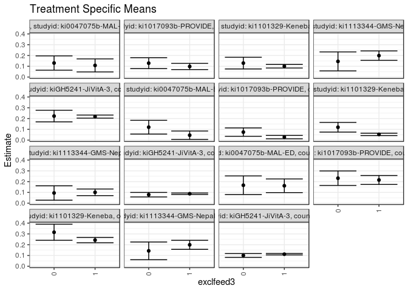

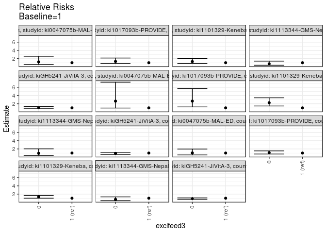

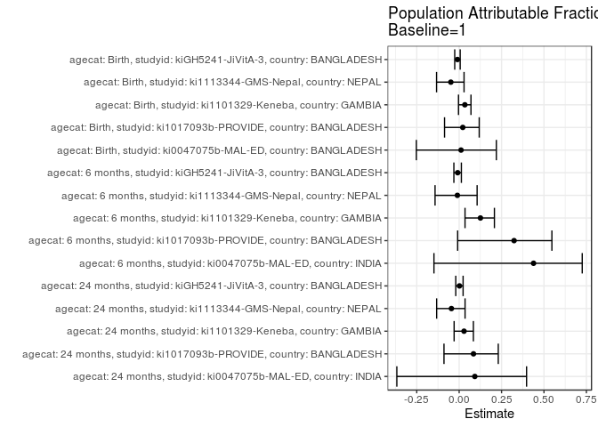

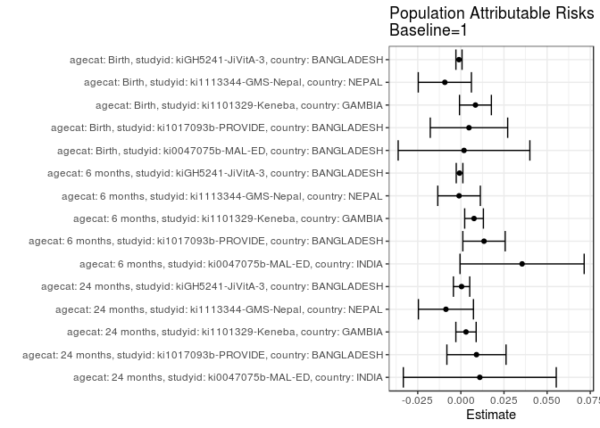

## Results Table

### Parameter: TSM

| agecat | studyid | country | intervention_level | baseline_level | estimate | ci_lower | ci_upper |
| --- | --- | --- | --- | --- | --- | --- | --- |
| Birth | ki0047075b-MAL-ED | BANGLADESH | 1 | NA | 0.1615385 | 0.0981174 | 0.2249595 |
| Birth | ki0047075b-MAL-ED | BANGLADESH | 0 | NA | 0.1666667 | 0.0803702 | 0.2529632 |
| Birth | ki1017093b-PROVIDE | BANGLADESH | 1 | NA | 0.2152231 | 0.1739172 | 0.2565290 |
| Birth | ki1017093b-PROVIDE | BANGLADESH | 0 | NA | 0.2317881 | 0.1644200 | 0.2991562 |
| Birth | ki1101329-Keneba | GAMBIA | 1 | NA | 0.2427184 | 0.2177448 | 0.2676921 |
| Birth | ki1101329-Keneba | GAMBIA | 0 | NA | 0.3154362 | 0.2407936 | 0.3900789 |
| Birth | ki1113344-GMS-Nepal | NEPAL | 1 | NA | 0.1988636 | 0.1571169 | 0.2406104 |
| Birth | ki1113344-GMS-Nepal | NEPAL | 0 | NA | 0.1428571 | 0.0607857 | 0.2249285 |
| Birth | kiGH5241-JiVitA-3 | BANGLADESH | 1 | NA | 0.1118721 | 0.1051014 | 0.1186429 |
| Birth | kiGH5241-JiVitA-3 | BANGLADESH | 0 | NA | 0.1002004 | 0.0824811 | 0.1179197 |
| 6 months | ki0047075b-MAL-ED | INDIA | 1 | NA | 0.0454545 | 0.0064356 | 0.0844735 |
| 6 months | ki0047075b-MAL-ED | INDIA | 0 | NA | 0.1200000 | 0.0561565 | 0.1838435 |
| 6 months | ki1017093b-PROVIDE | BANGLADESH | 1 | NA | 0.0280374 | 0.0123850 | 0.0436898 |
| 6 months | ki1017093b-PROVIDE | BANGLADESH | 0 | NA | 0.0742857 | 0.0354008 | 0.1131706 |
| 6 months | ki1101329-Keneba | GAMBIA | 1 | NA | 0.0532122 | 0.0420023 | 0.0644221 |
| 6 months | ki1101329-Keneba | GAMBIA | 0 | NA | 0.1194030 | 0.0745624 | 0.1642435 |
| 6 months | ki1113344-GMS-Nepal | NEPAL | 1 | NA | 0.1008174 | 0.0699785 | 0.1316564 |
| 6 months | ki1113344-GMS-Nepal | NEPAL | 0 | NA | 0.0945946 | 0.0278402 | 0.1613490 |
| 6 months | kiGH5241-JiVitA-3 | BANGLADESH | 1 | NA | 0.0876574 | 0.0809626 | 0.0943522 |
| 6 months | kiGH5241-JiVitA-3 | BANGLADESH | 0 | NA | 0.0789149 | 0.0580869 | 0.0997430 |
| 24 months | ki0047075b-MAL-ED | INDIA | 1 | NA | 0.1078431 | 0.0474980 | 0.1681883 |
| 24 months | ki0047075b-MAL-ED | INDIA | 0 | NA | 0.1300000 | 0.0639220 | 0.1960780 |
| 24 months | ki1017093b-PROVIDE | BANGLADESH | 1 | NA | 0.0980392 | 0.0691599 | 0.1269185 |
| 24 months | ki1017093b-PROVIDE | BANGLADESH | 0 | NA | 0.1286550 | 0.0784284 | 0.1788816 |
| 24 months | ki1101329-Keneba | GAMBIA | 1 | NA | 0.1004710 | 0.0839573 | 0.1169846 |
| 24 months | ki1101329-Keneba | GAMBIA | 0 | NA | 0.1292517 | 0.0750008 | 0.1835026 |
| 24 months | ki1113344-GMS-Nepal | NEPAL | 1 | NA | 0.1987578 | 0.1551132 | 0.2424023 |
| 24 months | ki1113344-GMS-Nepal | NEPAL | 0 | NA | 0.1451613 | 0.0573630 | 0.2329596 |
| 24 months | kiGH5241-JiVitA-3 | BANGLADESH | 1 | NA | 0.2182971 | 0.2040303 | 0.2325639 |
| 24 months | kiGH5241-JiVitA-3 | BANGLADESH | 0 | NA | 0.2230216 | 0.1693570 | 0.2766862 |

### Parameter: E(Y)

| agecat | studyid | country | intervention_level | baseline_level | estimate | ci_lower | ci_upper |
| --- | --- | --- | --- | --- | --- | --- | --- |
| Birth | ki0047075b-MAL-ED | BANGLADESH | NA | NA | 0.1633663 | 0.1122571 | 0.2144755 |
| Birth | ki1017093b-PROVIDE | BANGLADESH | NA | NA | 0.2199248 | 0.1846953 | 0.2551543 |
| Birth | ki1101329-Keneba | GAMBIA | NA | NA | 0.2511700 | 0.2274208 | 0.2749193 |
| Birth | ki1113344-GMS-Nepal | NEPAL | NA | NA | 0.1895735 | 0.1521320 | 0.2270149 |
| Birth | kiGH5241-JiVitA-3 | BANGLADESH | NA | NA | 0.1107768 | 0.1043978 | 0.1171557 |
| 6 months | ki0047075b-MAL-ED | INDIA | NA | NA | 0.0809524 | 0.0439731 | 0.1179317 |
| 6 months | ki1017093b-PROVIDE | BANGLADESH | NA | NA | 0.0414594 | 0.0255348 | 0.0573839 |
| 6 months | ki1101329-Keneba | GAMBIA | NA | NA | 0.0608496 | 0.0496205 | 0.0720787 |
| 6 months | ki1113344-GMS-Nepal | NEPAL | NA | NA | 0.0997732 | 0.0717702 | 0.1277763 |
| 6 months | kiGH5241-JiVitA-3 | BANGLADESH | NA | NA | 0.0868958 | 0.0805887 | 0.0932029 |
| 24 months | ki0047075b-MAL-ED | INDIA | NA | NA | 0.1188119 | 0.0740803 | 0.1635435 |
| 24 months | ki1017093b-PROVIDE | BANGLADESH | NA | NA | 0.1070812 | 0.0818727 | 0.1322897 |
| 24 months | ki1101329-Keneba | GAMBIA | NA | NA | 0.1034483 | 0.0876083 | 0.1192882 |
| 24 months | ki1113344-GMS-Nepal | NEPAL | NA | NA | 0.1901042 | 0.1508072 | 0.2294011 |
| 24 months | kiGH5241-JiVitA-3 | BANGLADESH | NA | NA | 0.2187047 | 0.2046312 | 0.2327783 |

### Parameter: RR

| agecat | studyid | country | intervention_level | baseline_level | estimate | ci_lower | ci_upper |
| --- | --- | --- | --- | --- | --- | --- | --- |
| Birth | ki0047075b-MAL-ED | BANGLADESH | 1 | 1 | 1.0000000 | 1.0000000 | 1.000000 |
| Birth | ki0047075b-MAL-ED | BANGLADESH | 0 | 1 | 1.0317460 | 0.5387284 | 1.975949 |
| Birth | ki1017093b-PROVIDE | BANGLADESH | 1 | 1 | 1.0000000 | 1.0000000 | 1.000000 |
| Birth | ki1017093b-PROVIDE | BANGLADESH | 0 | 1 | 1.0769666 | 0.7602217 | 1.525683 |
| Birth | ki1101329-Keneba | GAMBIA | 1 | 1 | 1.0000000 | 1.0000000 | 1.000000 |
| Birth | ki1101329-Keneba | GAMBIA | 0 | 1 | 1.2995973 | 1.0040278 | 1.682178 |
| Birth | ki1113344-GMS-Nepal | NEPAL | 1 | 1 | 1.0000000 | 1.0000000 | 1.000000 |
| Birth | ki1113344-GMS-Nepal | NEPAL | 0 | 1 | 0.7183673 | 0.3896809 | 1.324293 |
| Birth | kiGH5241-JiVitA-3 | BANGLADESH | 1 | 1 | 1.0000000 | 1.0000000 | 1.000000 |
| Birth | kiGH5241-JiVitA-3 | BANGLADESH | 0 | 1 | 0.8956689 | 0.7436255 | 1.078799 |
| 6 months | ki0047075b-MAL-ED | INDIA | 1 | 1 | 1.0000000 | 1.0000000 | 1.000000 |
| 6 months | ki0047075b-MAL-ED | INDIA | 0 | 1 | 2.6399999 | 0.9616175 | 7.247788 |
| 6 months | ki1017093b-PROVIDE | BANGLADESH | 1 | 1 | 1.0000000 | 1.0000000 | 1.000000 |
| 6 months | ki1017093b-PROVIDE | BANGLADESH | 0 | 1 | 2.6495238 | 1.2325604 | 5.695442 |
| 6 months | ki1101329-Keneba | GAMBIA | 1 | 1 | 1.0000000 | 1.0000000 | 1.000000 |
| 6 months | ki1101329-Keneba | GAMBIA | 0 | 1 | 2.2439024 | 1.4588147 | 3.451500 |
| 6 months | ki1113344-GMS-Nepal | NEPAL | 1 | 1 | 1.0000000 | 1.0000000 | 1.000000 |
| 6 months | ki1113344-GMS-Nepal | NEPAL | 0 | 1 | 0.9382761 | 0.4348109 | 2.024701 |
| 6 months | kiGH5241-JiVitA-3 | BANGLADESH | 1 | 1 | 1.0000000 | 1.0000000 | 1.000000 |
| 6 months | kiGH5241-JiVitA-3 | BANGLADESH | 0 | 1 | 0.9002656 | 0.6820330 | 1.188327 |
| 24 months | ki0047075b-MAL-ED | INDIA | 1 | 1 | 1.0000000 | 1.0000000 | 1.000000 |
| 24 months | ki0047075b-MAL-ED | INDIA | 0 | 1 | 1.2054545 | 0.5660335 | 2.567199 |
| 24 months | ki1017093b-PROVIDE | BANGLADESH | 1 | 1 | 1.0000000 | 1.0000000 | 1.000000 |
| 24 months | ki1017093b-PROVIDE | BANGLADESH | 0 | 1 | 1.3122807 | 0.8046925 | 2.140048 |
| 24 months | ki1101329-Keneba | GAMBIA | 1 | 1 | 1.0000000 | 1.0000000 | 1.000000 |
| 24 months | ki1101329-Keneba | GAMBIA | 0 | 1 | 1.2864583 | 0.8196550 | 2.019112 |
| 24 months | ki1113344-GMS-Nepal | NEPAL | 1 | 1 | 1.0000000 | 1.0000000 | 1.000000 |
| 24 months | ki1113344-GMS-Nepal | NEPAL | 0 | 1 | 0.7303427 | 0.3837740 | 1.389882 |
| 24 months | kiGH5241-JiVitA-3 | BANGLADESH | 1 | 1 | 1.0000000 | 1.0000000 | 1.000000 |
| 24 months | kiGH5241-JiVitA-3 | BANGLADESH | 0 | 1 | 1.0216424 | 0.7989659 | 1.306380 |

### Parameter: PAR

| agecat | studyid | country | intervention_level | baseline_level | estimate | ci_lower | ci_upper |
| --- | --- | --- | --- | --- | --- | --- | --- |
| Birth | ki0047075b-MAL-ED | BANGLADESH | 1 | NA | 0.0018279 | -0.0363461 | 0.0400018 |
| Birth | ki1017093b-PROVIDE | BANGLADESH | 1 | NA | 0.0047017 | -0.0177367 | 0.0271402 |
| Birth | ki1101329-Keneba | GAMBIA | 1 | NA | 0.0084516 | -0.0007850 | 0.0176882 |
| Birth | ki1113344-GMS-Nepal | NEPAL | 1 | NA | -0.0092902 | -0.0246930 | 0.0061127 |
| Birth | kiGH5241-JiVitA-3 | BANGLADESH | 1 | NA | -0.0010954 | -0.0028761 | 0.0006853 |
| 6 months | ki0047075b-MAL-ED | INDIA | 1 | NA | 0.0354978 | -0.0004879 | 0.0714835 |
| 6 months | ki1017093b-PROVIDE | BANGLADESH | 1 | NA | 0.0134220 | 0.0011420 | 0.0257019 |
| 6 months | ki1101329-Keneba | GAMBIA | 1 | NA | 0.0076374 | 0.0022125 | 0.0130623 |
| 6 months | ki1113344-GMS-Nepal | NEPAL | 1 | NA | -0.0010442 | -0.0133851 | 0.0112967 |
| 6 months | kiGH5241-JiVitA-3 | BANGLADESH | 1 | NA | -0.0007616 | -0.0026838 | 0.0011607 |
| 24 months | ki0047075b-MAL-ED | INDIA | 1 | NA | 0.0109687 | -0.0333580 | 0.0552955 |
| 24 months | ki1017093b-PROVIDE | BANGLADESH | 1 | NA | 0.0090420 | -0.0081069 | 0.0261908 |
| 24 months | ki1101329-Keneba | GAMBIA | 1 | NA | 0.0029773 | -0.0029068 | 0.0088614 |
| 24 months | ki1113344-GMS-Nepal | NEPAL | 1 | NA | -0.0086536 | -0.0246070 | 0.0072998 |
| 24 months | kiGH5241-JiVitA-3 | BANGLADESH | 1 | NA | 0.0004076 | -0.0043247 | 0.0051400 |

### Parameter: PAF

| agecat | studyid | country | intervention_level | baseline_level | estimate | ci_lower | ci_upper |
| --- | --- | --- | --- | --- | --- | --- | --- |
| Birth | ki0047075b-MAL-ED | BANGLADESH | 1 | NA | 0.0111888 | -0.2523813 | 0.2192893 |
| Birth | ki1017093b-PROVIDE | BANGLADESH | 1 | NA | 0.0213787 | -0.0861288 | 0.1182449 |
| Birth | ki1101329-Keneba | GAMBIA | 1 | NA | 0.0336489 | -0.0037837 | 0.0696856 |
| Birth | ki1113344-GMS-Nepal | NEPAL | 1 | NA | -0.0490057 | -0.1331673 | 0.0289051 |
| Birth | kiGH5241-JiVitA-3 | BANGLADESH | 1 | NA | -0.0098883 | -0.0260513 | 0.0060202 |
| 6 months | ki0047075b-MAL-ED | INDIA | 1 | NA | 0.4385027 | -0.1484993 | 0.7254859 |
| 6 months | ki1017093b-PROVIDE | BANGLADESH | 1 | NA | 0.3237383 | -0.0088626 | 0.5466876 |
| 6 months | ki1101329-Keneba | GAMBIA | 1 | NA | 0.1255127 | 0.0346530 | 0.2078206 |
| 6 months | ki1113344-GMS-Nepal | NEPAL | 1 | NA | -0.0104657 | -0.1420133 | 0.1059291 |
| 6 months | kiGH5241-JiVitA-3 | BANGLADESH | 1 | NA | -0.0087641 | -0.0311034 | 0.0130913 |
| 24 months | ki0047075b-MAL-ED | INDIA | 1 | NA | 0.0923203 | -0.3672710 | 0.3974256 |
| 24 months | ki1017093b-PROVIDE | BANGLADESH | 1 | NA | 0.0844402 | -0.0894183 | 0.2305529 |
| 24 months | ki1101329-Keneba | GAMBIA | 1 | NA | 0.0287807 | -0.0296568 | 0.0839017 |
| 24 months | ki1113344-GMS-Nepal | NEPAL | 1 | NA | -0.0455203 | -0.1326078 | 0.0348709 |
| 24 months | kiGH5241-JiVitA-3 | BANGLADESH | 1 | NA | 0.0018639 | -0.0199951 | 0.0232544 |